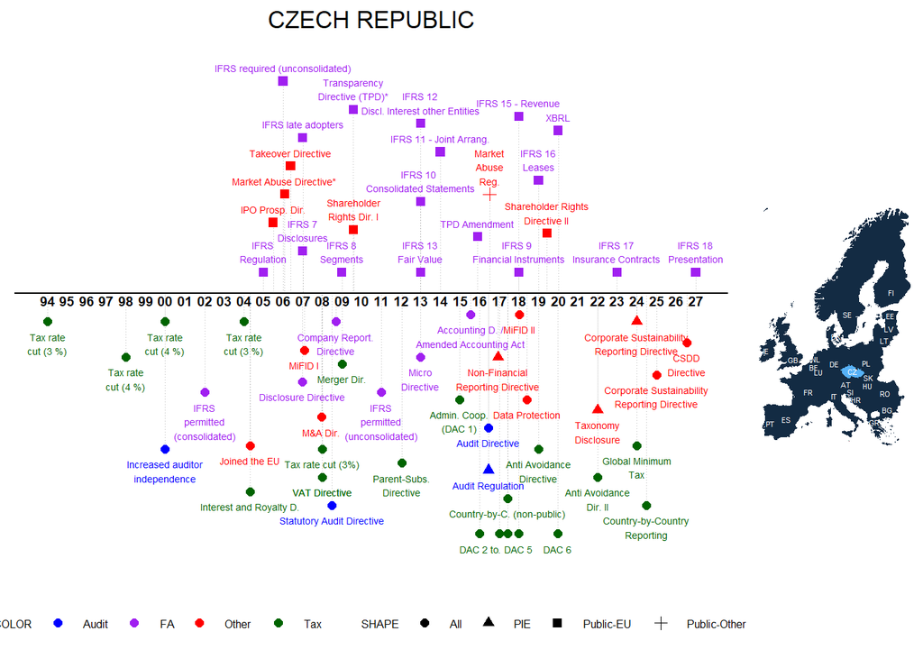

Notes: The graph depicts major regulatory changes that we identified via an extensive literature search, an online survey of mentioned authors, and other sources. Please note that the graph does not include all possible regulatory changes, e.g. minor revisions to local GAAP or tax rate changes below 3% are not included. The dates of EU Directives are based on the official transposition deadlines unless denoted with a *, in which case we included the entry-to-force date as identified in the literature. For more information, please go to [Labro and Pierk (2025)](https://link.springer.com/article/10.1007/s11142-025-09909-0). We kindly ask that you cite the paper if you use the information on this website in your research project. Do you have comments or see anything missing? Please email us!

## Regulations, Publications, Further Graphs

The tab ‘Regulations’ includes links to the regulations, gives short descriptions, and provides selective papers for further reading. If the regulation is a national transposition of an EU Directive, the link to the Directive is given. The tab ‘Number of Regulations’ shows graphically the number of regulations 8 years around the respective year (-4,-3,-2,-1,0,+1,+2,+3). The tab ‘Number of Categories” shows graphically the number of different categories 8 years around the respective year (-4,-3,-2,-1,0,+1,+2,+3). The tab ’Publications’ shows all publications that include the countries’ names and variations thereof in the title, abstract, or keywords. Similarly, the tab ‘SSRN’ shows papers of the SSRN Accouning Research Network that include the countries’ names and variations.

### Regulations

[output not shown]

[output cut: 55 more lines]

### Number of Regulations

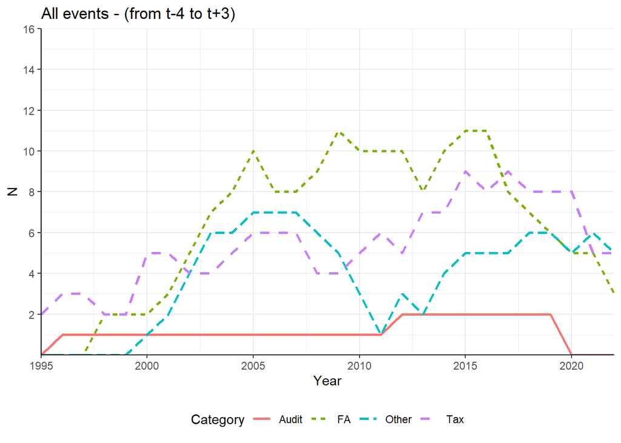

### Number of Categories

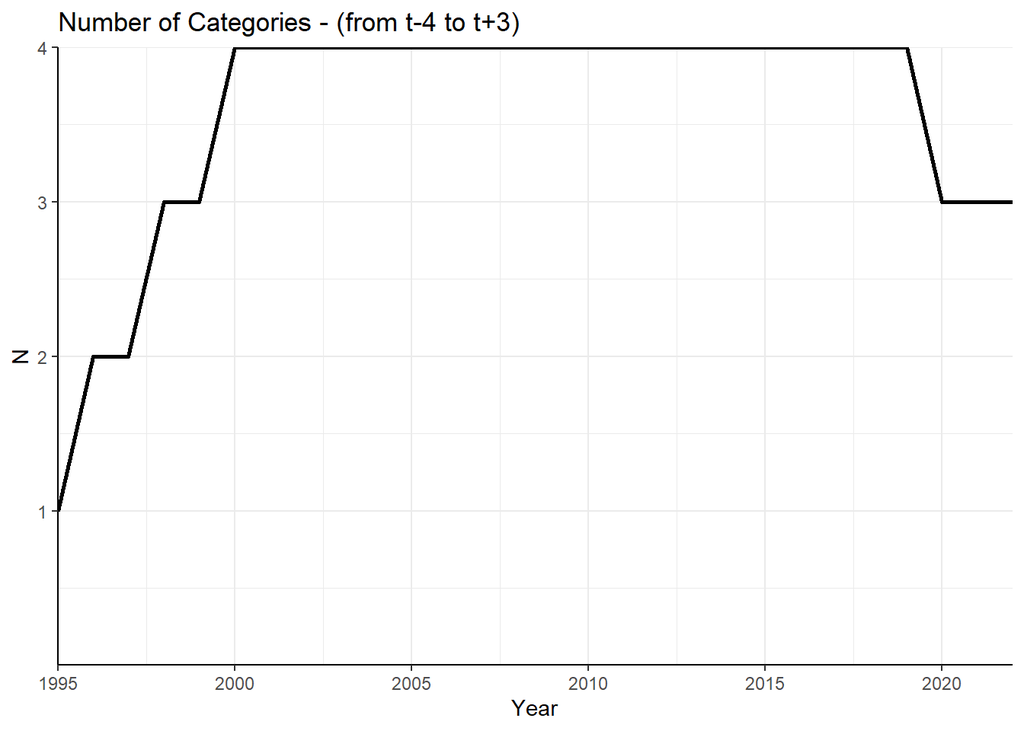

### Publications

|  | authors | title | year | journal |
| --- | --- | --- | --- | --- |
| 1 | Uddin S., Popesko B., Papadaki Š., Wagner J. | performance measurement in a transitional economy: unfolding a case of kpis | 2021 | Accounting, Auditing and Accountability Journal |
| 2 | Jindrichovska I., Kubickova D. | the role and current status of ifrs in the completion of national accounting rules–evidence from the czech republic | 2017 | Accounting in Europe |
| 3 | Bonsón E., Escobar T. | digital reporting in eastern europe: an empirical study | 2006 | International Journal of Accounting Information Systems |
| 4 | Hellström K. | the value relevance of financial accounting information in a transition economy: the case of the czech republic | 2006 | European Accounting Review |
| 5 | Jindrichovska I., Mcleay S. | accounting for good news and accounting for bad news: some empirical evidence from the czech republic | 2005 | European Accounting Review |
| 6 | Sucher P., Kosmala-MacLullich K. | a construction of auditor independence in the czech republic: local insights | 2004 | Accounting, Auditing & Accountability Journal |
| 7 | Eilifsen A., Knechel W.R., Wallage P. | application of the business risk audit model: a field study | 2001 | Accounting Horizons |
| 8 | Jindrichovska I. | the relationship between accounting numbers and returns: some empirical evidence from the emerging market of the czech republic | 2001 | European Accounting Review |
| 9 | Sucher P., Moizer P., Zarova M. | the images of the big six audit firms in the czech republic | 1999 | European Accounting Review |
| 10 | Sucher P., Zelenka I., IV | the development of the role of the audit in the czech republic | 1998 | European Accounting Review |

[output cut: 6 more lines]

### SSRN

|  | authors | title | Posted | Revised |
| --- | --- | --- | --- | --- |
| 1 | Bohumil Král, Grzegorz Mikołajewicz, Jarosław Nowicki and Libuše Šoljaková | management accountants' professional competences: requirements in the czech republic and poland. the normative approach and business practice | 2021-11-18 | 2021-12-15 |
| 2 | Jan Hájek and Cecilia Olexová | comparing personal income tax gap in the czech republic and the slovak republic | 2021-11-08 |  |
| 3 | Deni Mazrekaj, Vítězslav Titl and Fritz Schiltz | identifying politically connected firms: a machine learning approach | 2021-06-14 |  |
| 4 | Jiri Witzany and Olga Pastiranová | impact of the implementation of ifrs 9 on the czech banking sector | 2021-06-04 |  |
| 5 | Hana Zídková and Tomáš Vrána | is vat administration system efficient? the case of the czech republic | 2021-03-22 |  |
| 6 | Irena Jindrichovska and Vyacheslav Moskalchuk | influence of corporate taxation on the financial leverage of czech, polish and russian companies | 2020-07-21 |  |
| 7 | Michal Radvan | immovable property tax exemptions as a tool of tax policy | 2020-03-10 |  |